# HNU2000 - Session 3

## Annotation sémantique et annotation stylistique

- WYSIWYG = What You See Is What You Get
- WYSIWYM = What You See Is What You Mean

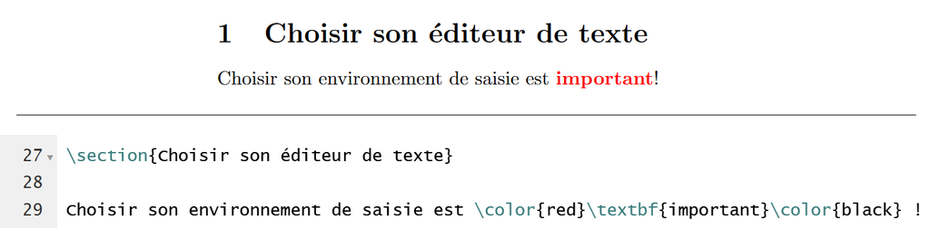

- annotation stylistique:
  - dimension graphique: le sens n’est conservé que si la mise en forme est conservée (gras, italique, couleur, etc.)
  - la mise en forme dépend du support de publication (page web, PDF, impression, etc.) et doit être adaptée à chaque support
  - la mise en forme est souvent difficile à maintenir dans le temps
- annotation sémantique:
  - dimension structurelle: le sens est conservé indépendamment de la mise en forme
  - la structure est conservée et peut être adaptée à différents supports de publication
  - la structure est plus facile à maintenir dans le temps

## Editeurs de texte WYSIWYG

- Word, LibreOffice, Google Docs, etc.
- simulation d’une feuille de papier ([skeuomorphisme](https://fr.wikipedia.org/wiki/Skeuomorphisme)) et d’un environnement de saisie type “machine à écrire”
- options de mise en forme avec rendu immédiat
- dimension sémantique limitée: passe par les *calques* de mise en forme ou *styles* (titre, titre 1, titre 2, paragraph, etc.)
  - se traduit par la capacité à créer une table des matières, etc.
  - mais se traduit par des options de mise en forme limitées et des difficultés à maintenir la cohérence de la mise en forme

## Editeurs de texte WYSIWYM et formats de balisage

- **balisage** = ajout de balises pour structurer le texte
- les balises apparaissent quand un texte est ouvert dans un éditeur de texte WISIWYM
- exemples de syntaxes de balisage:
  - HTML et XML : `<balise attribut="valeur">contenu</balise>`
  - LaTeX : `\commande{argument}`
- le balisage permet de structurer le document mais aussi d’annoter des éléments du texte (section mise en exergue, information sémantique, ajout de notes, etc.) et des métadonnées.

**HTML** est un format de balisage:

### Sans rendu stylistique

```html
<!DOCTYPE html>
<html>
  <head>
    <title>Titre de la page</title>
  </head>
  <body>
    <h1>Titre de niveau 1</h1>
    <p>Paragraphe</p>
  </body>
</html>
```

### Avec rendu stylistique

# Titre de niveau 1

Paragraphe

## Regardons HTML de plus près

- https://www.editions-zones.fr/lyber?eloge-du-bug

## Markdown 101

- balisage léger (facile à lire et à écrire)
- syntaxe simple pour structurer un document
- mais usage limité (on fait plus de choses avec XML, HTML ou LaTeX qu’avec Markdown)
- conversion en HTML, PDF, DOCX, etc.

### Les éléments de bases de Markdown

```markdown
# Titre de niveau 1

## Titre de niveau 2

etc

###### Titre de niveau 6

**Texte en gras**

*Texte en italique*


Liste non-numéroté:

- élément 1
- élément 2


Liste numérotée:

1. élément 1
2. élément 2


[texte du lien](url)

![texte alternatif](url de l'image)

[^note de bas de page] + [^note de bas de page]: texte de la note de bas de page
```

Il existe des variantes de Markdown ([GitHub Flavored Markdown](https://docs.github.com/fr/get-started/writing-on-github/getting-started-with-writing-and-formatting-on-github/basic-writing-and-formatting-syntax), [GItlab flavored Markdown](https://docs.gitlab.com/ee/user/markdown.html), CommonMark, etc.) qui ajoutent des fonctionnalités supplémentaires.

Par exemple:

- tableaux

```markdown
| Entête 1   | Entête 2   |
| ---------- | ---------- |
| cellule 1  | cellule 2  |
```

| Entête 1 | Entête 2 |
| --- | --- |
| cellule 1 | cellule 2 |

- blocs de code

```

code

```

- surlignage (`{+ texte +}`)

## Markdown dans la pratique

- Markdown est utilisé pour écrire des README sur GitHub, des articles sur des plateformes de blogging, des messages sur des forums, ou même ce cours!
- Markdown est utilisé pour écrire des documents dans des éditeurs de texte WYSIWYM comme Stylo, Jupyter, etc.
- Markdown est souvent couplé à des languages plus avancés quand on veut faire des choses plus complexes (HTML, LaTeX, etc.)

```markdown
# Titre de niveau 1

Ceci est une formule mathématique faisant appel à la syntaxe LaTeX dans un document Markdown: $e^{i\pi} + 1 = 0$

Ceci est une balise html pour ajouter une image dans un document Markdown en utilisant d'autres propriétés: <img src="url_de_l'image" alt="texte alternatif" width="200"/>
```

- Tous les éditeurs ne supportent pas les mêmes fonctionnalités de Markdown.
- Les fichiers Markdown ont souvent l’extension `.md`
- Ils peuvent être parsés pour générer des fichiers HTML, PDF, DOCX, etc, par exemple avec [pandoc](https://pandoc.org/).
- Apprendre à utiliser Markdown en 5 minutes: https://www.markdowntutorial.com/
- Tester Markdown dans un éditeur en ligne: https://dillinger.io/

## Présentation de Stylo

- https://stylo.huma-num.fr/
- Chaire de recherche du Canada sur les écritures numériques
- Hébergement par la TGDIR HumaNum
- éditeur de texte sémantique pour la rédaction scientifique
- écrire, structurer, prévisualiser, réviser, exporter
- utilisation d’un langage de balisage léger (Markdown), d’un langage de description de métadonnées (YAML) et d’un langage de description bibliographique (BibTeX)
- application en ligne, simple d’utilisation
- utilisation de briques logicielles existantes (et libres)
- possible de créer un compte via Huma-Num (prévoir temps de validation) ou sans passer par Huma-Num (mais pas de possibilité de récupération de mot de passe!)

## Markdown dans Stylo

- Stylo utilise Markdown pour structurer le texte
- https://stylo-doc.ecrituresnumeriques.ca/fr/syntaxemarkdown/

## Manipulation de Stylo

### Préparation

- on travaille à partir de [Mounier Pierre, Dacos Marin. *Édition électronique*. In: *Communications*, 88, 2011. Cultures du numérique, sous la direction de Antonio A. Casilli. pp. 47-55. DOI: https://doi.org/10.3406/comm.2011.2584](https://www.persee.fr/doc/comm_0588-8018_2011_num_88_1_2584)
- parcourir le document et relever la structure sémantique et les différentes annotations
- *dans Stylo*, créer un nouveau document nommé `NOM_HNU2000_automne2024`
- récupérer la version texte de l’article (bouton dans le menu de gauche) et coller dans le nouveau document Stylo
- (opt) utiliser les expressions régulière pour nettoyer le texte si nécessaire
- *si nécessaire, le TXT propre est ici: https://raw.githubusercontent.com/alix-tz/hnu2000-a24/main/mounier_dacos_stylo.txt*

### Structuration sémantique

- utiliser Markdown pour structurer le texte de l’article en s’appuyant sur la version graphique
  - niveaux de titre
  - italiques
  - notes de bas de page

### Métadonnées

- utiliser l’onglet “Métadonnées” pour ajouter des métadonnées

### Partage

- partager le document Stylo avec `alix.chague@inria.fr`

### Export

- exporter le document en HTML
- exporter le document en PDF
- exporter le document en DOCX
- comparer les différentes options et les résultats obtenus